# Brian Michira Week 12 IP R Fundamentals

## 3.Exploratory Data Analysis

## Univariate Analysis

### Daily Time Spent on Site

#### 1. Measures of Central Tendency

```r
# mean
mean(dataset$Daily.Time.Spent.on.Site)
```

```
## [1] 65.0002
```

The Mean pf the Time Spent on Site Daily is 65.0002.

```r
# median
median(dataset$Daily.Time.Spent.on.Site)
```

```
## [1] 68.215
```

The Median of the Time Spent on Site Daily is 68.215.

```r
# mode
getmode <- function(v) {
   uniqv <- unique(v)
   uniqv[which.max(tabulate(match(v, uniqv)))]
}

getmode(dataset$Daily.Time.Spent.on.Site)
```

```
## [1] 62.26
```

The most common time Spent on site is 62.26.

#### 2.Measure of Dispersion

```r
#Standard Deviation
sd(dataset$Daily.Time.Spent.on.Site)
```

```
## [1] 15.85361
```

The Standard Deviation of Daily Time Spent on Site is 15.85361.

```r
#Variance
var(dataset$Daily.Time.Spent.on.Site)
```

```
## [1] 251.3371
```

The Variance of Daily Time Spent on Site is 251.3371.

```r
#Range
range(dataset$Daily.Time.Spent.on.Site)
```

```
## [1] 32.60 91.43
```

The range of Daily Time Spent on Site was 32.60 on the minimum and 91.43 on the maximum.

```r
#Quantile
quantile(dataset$Daily.Time.Spent.on.Site)
```

```
##      0%     25%     50%     75%    100%
## 32.6000 51.3600 68.2150 78.5475 91.4300
```

### Age

#### 1.Measure of Central Tendancy

```r
# mean
mean(dataset$Age)
```

```
## [1] 36.009
```

The mean Age is 36 years.

```r
# median
median(dataset$Age)
```

```
## [1] 35
```

The median Age is 35 years

```r
# mode
getmode <- function(v) {
   uniqv <- unique(v)
   uniqv[which.max(tabulate(match(v, uniqv)))]
}

getmode(dataset$Age)
```

```
## [1] 31
```

Most people had 31 years.

#### 2.Measure of Dispersion

```r
#Variance
var(dataset$Age)
```

```
## [1] 77.18611
```

The variance of age is 77.18611.

```r
#Standard Deviation
sd(dataset$Age)
```

```
## [1] 8.785562
```

The Standard Deviation of Age is 8.785562.

```r
#range
range(dataset$Age)
```

```
## [1] 19 61
```

The minimum age is 19 years and the maximmum age is 61 years.

```r
#Quantile
quantile(dataset$Age)
```

```
##   0%  25%  50%  75% 100%
##   19   29   35   42   61
```

### Area Income

#### 1.Measure of Central Tendency

```r
#Mean
mean(dataset$Area.Income)
```

```
## [1] 55000
```

The mean Area income is 55,000.

```r
#median
median(dataset$Area.Income)
```

```
## [1] 57012.3
```

The median Area Income is 57012.3.

```r
# mode
getmode <- function(v) {
   uniqv <- unique(v)
   uniqv[which.max(tabulate(match(v, uniqv)))]
}

getmode(dataset$Area.Income)
```

```
## [1] 61833.9
```

The common Area Income is 61,833.9.

#### 2.Measure of Dispersion

```r
#Variance
var(dataset$Area.Income)
```

```
## [1] 179952406
```

The Variance of Area Income is 179952406.

```r
#Standard Deviation
sd(dataset$Area.Income)
```

```
## [1] 13414.63
```

The Standard Deviation of Area Income is 13414.63.

```r
#Range
range(dataset$Area.Income)
```

```
## [1] 13996.5 79484.8
```

The minimum Area Income is 13996.5 and the maximum Area Income is 79484.8.

```r
#quantile
quantile(dataset$Area.Income)
```

```
##       0%      25%      50%      75%     100%
## 13996.50 47031.80 57012.30 65470.64 79484.80
```

### Daily Internet Usage

#### 1.Measure of central Tendecy

```r
#mean
mean(dataset$Daily.Internet.Usage)
```

```
## [1] 180.0001
```

The Mean Internet Usage is 180.0001.

```r
#median
median(dataset$Daily.Internet.Usage)
```

```
## [1] 183.13
```

The Median internet usage is 183.13.

```r
# mode
getmode <- function(v) {
   uniqv <- unique(v)
   uniqv[which.max(tabulate(match(v, uniqv)))]
}

getmode(dataset$Daily.Internet.Usage)
```

```
## [1] 167.22
```

The most common Internet Usage is 167.22.

## Graphical representation of univariate ananlysis

###Daily Time Spent on Site

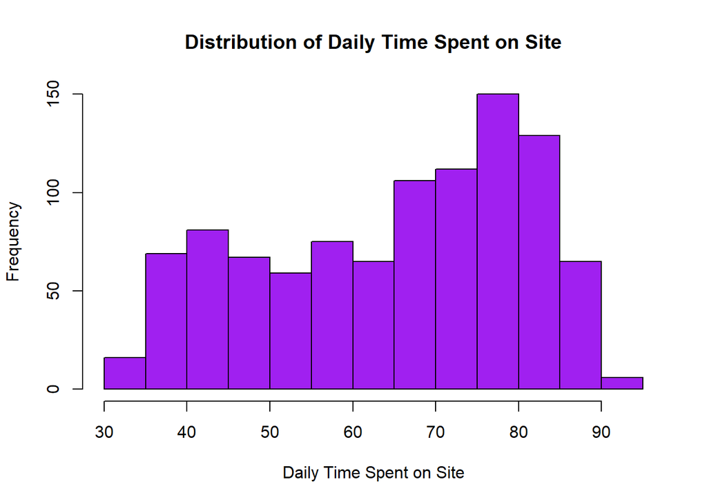

```r
hist(dataset$Daily.Time.Spent.on.Site,main = "Distribution of Daily Time Spent on Site",col="purple"
    ,xlab="Daily Time Spent on Site")
```

The duration between 75 and 85 had the highest frequency.

### Age

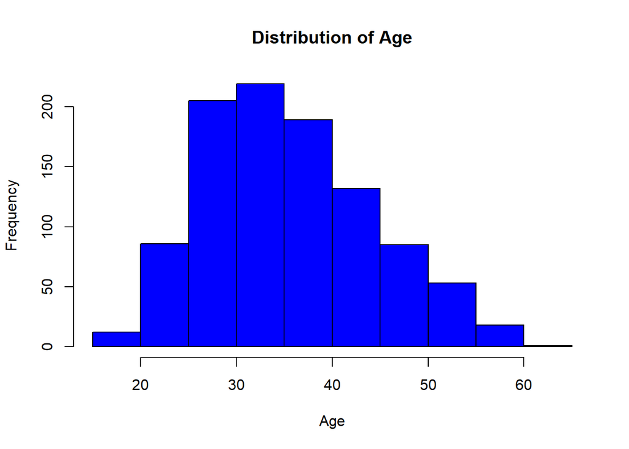

```r
hist(dataset$Age,main = "Distribution of Age",col="blue",
     xlab="Age")
```

The age between 25 years and 35 years had the highest frequency. Age is skewed to the right.

### Area Income

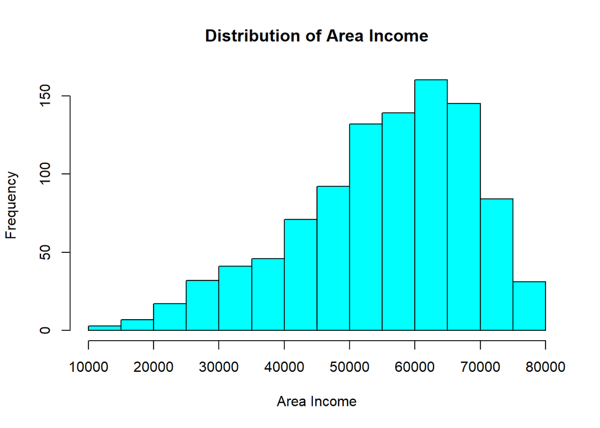

```r
hist(dataset$Area.Income,main = "Distribution of Area Income",col="Cyan",
     xlab = "Area Income")
```

The Income between 60,000 and 70,000 had the highest frequency.

### Daily Internet Usage

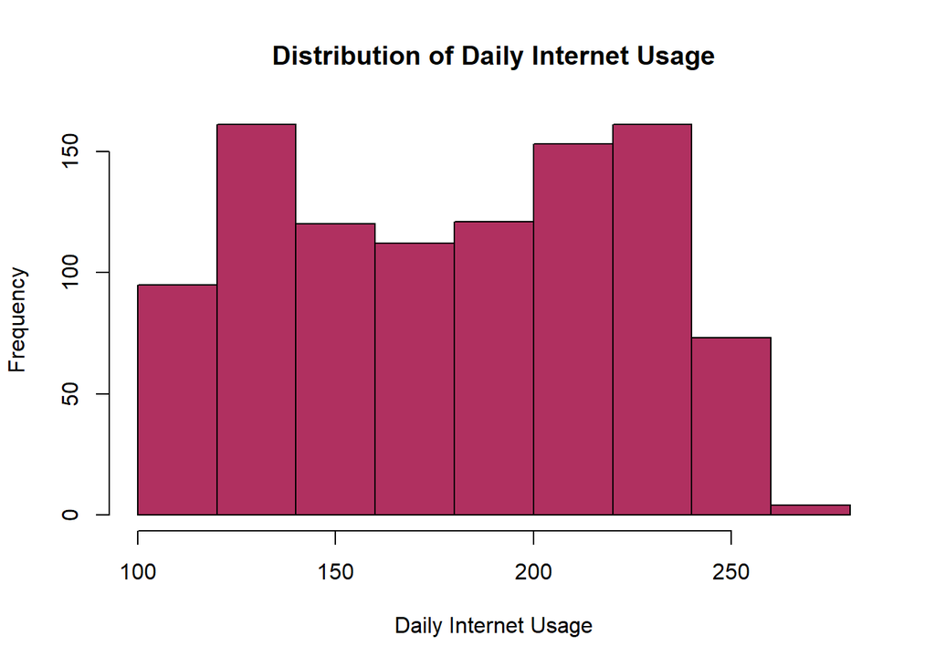

```r
hist(dataset$Daily.Internet.Usage,main = "Distribution of Daily Internet Usage",col="maroon",
     xlab="Daily Internet Usage")
```

The usage between 200 and 250 had the highest frequency. Daily internet usage is Bimodal.

### Univariate Analysis of Categorical Data

```r
Gender <- dataset$Male
frequency<- table(Gender)
frequency
```

```
## Gender
##   0   1
## 519 481
```

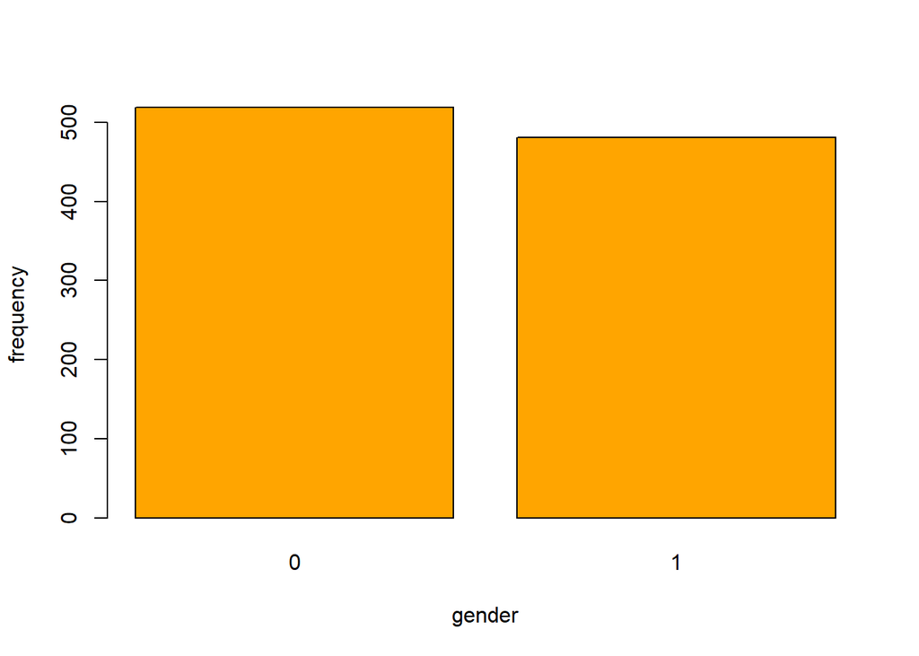

```r
barplot(frequency,xlab ="gender", ylab = "frequency", col="orange")
```

Majority of the respondents were female.519 females 481 males.

```r
Ads <- dataset$Clicked.on.Ad
frequency<- table(Ads)
frequency
```

```
## Ads
##   0   1
## 500 500
```

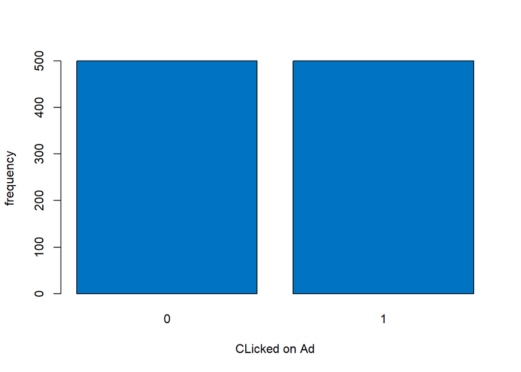

```r
barplot(frequency,xlab ="CLicked on Ad", ylab = "frequency", col="#0073C2FF")
```

## 2.Bivariate Analysis

### (i)Covariance

```r
# covariance between daily time spent on site and age
cov(dataset$Daily.Time.Spent.on.Site,dataset$Age)
```

```
## [1] -46.17415
```

The covariance between daily time spent on site and age is -46.17. It indicates a negative linear relationship between the two variables.

```r
# covariance between area income and daily internet usage
cov(dataset$Area.Income,dataset$Daily.Internet.Usage)
```

```
## [1] 198762.5
```

The covariance between area income and daily internet usage is 198762.5. It indicates a positive linear relationship between the two variables.

```r
# covariance between daily internet usage and age
cov(dataset$Daily.Internet.Usage,dataset$Age)
```

```
## [1] -141.6348
```

The covariance between daily internet usage and age is -141.6348. It indicates a negative linear relationship between the two variables.

### (ii)Correlation

```r
# correlation coefficient between area income and daily internet usage
cor(dataset$Area.Income,dataset$Daily.Internet.Usage)
```

```
## [1] 0.3374955
```

The correlation coefficient between area income and daily internet usage is 0.3375.

```r
# correlation coefficient between daily time spent on site and area income
cor(dataset$Daily.Time.Spent.on.Site,dataset$Area.Income)
```

```
## [1] 0.3109544
```

The correlation coefficient between daily time spent on site and area income is 0.311.

```r
#correlation matrix
cor(dataset[,unlist(lapply(dataset, is.numeric))])
```

```
##                          Daily.Time.Spent.on.Site         Age  Area.Income
## Daily.Time.Spent.on.Site               1.00000000 -0.33151334  0.310954413
## Age                                   -0.33151334  1.00000000 -0.182604955
## Area.Income                            0.31095441 -0.18260496  1.000000000
## Daily.Internet.Usage                   0.51865848 -0.36720856  0.337495533
## Male                                  -0.01895085 -0.02104406  0.001322359
## Clicked.on.Ad                         -0.74811656  0.49253127 -0.476254628
##                          Daily.Internet.Usage         Male Clicked.on.Ad
## Daily.Time.Spent.on.Site           0.51865848 -0.018950855   -0.74811656
## Age                               -0.36720856 -0.021044064    0.49253127
## Area.Income                        0.33749553  0.001322359   -0.47625463
## Daily.Internet.Usage               1.00000000  0.028012326   -0.78653918
## Male                               0.02801233  1.000000000   -0.03802747
## Clicked.on.Ad                     -0.78653918 -0.038027466    1.00000000
```

From the correlation matrix looking at the clicked on AD we can see that its only age that has a positive correlation with Clicked on AD. We can confirm this by conducting the point Biserial correlation which is used to test correlation between a continuos and a categorical variable.

```r
#Biserial correlation
cor.test(dataset$Age,dataset$Clicked.on.Ad)
```

```
##
##  Pearson's product-moment correlation
##
## data:  dataset$Age and dataset$Clicked.on.Ad
## t = 17.879, df = 998, p-value < 2.2e-16
## alternative hypothesis: true correlation is not equal to 0
## 95 percent confidence interval:
##  0.4440981 0.5380944
## sample estimates:
##       cor
## 0.4925313
```

We found a correlation coefficient of 0.492 which show there is a positive correlation between Age and Clicked on Ad.

#### (iii)Scatter plots

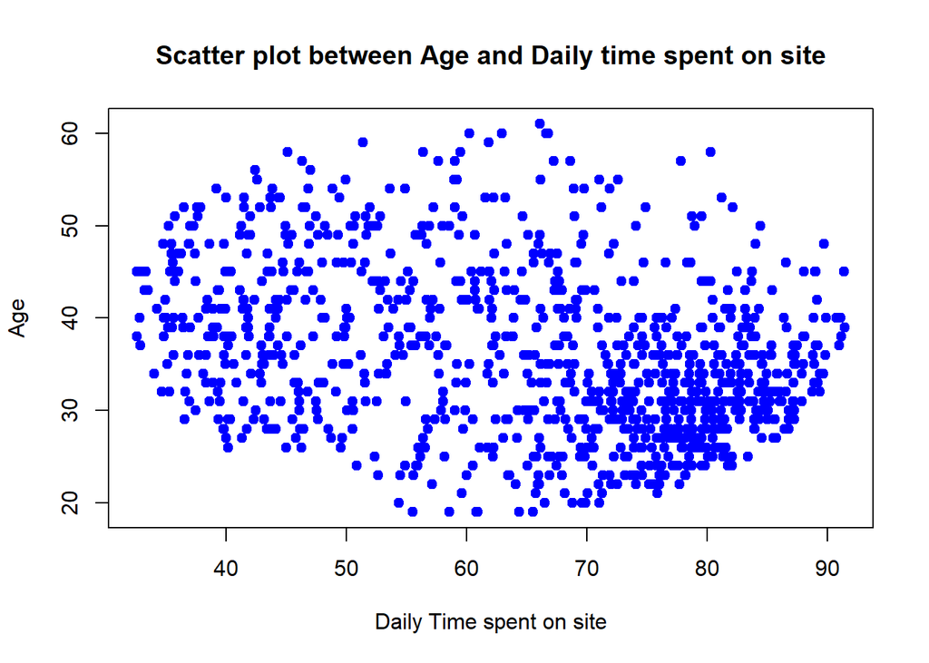

```r
# scatter plot between age and daily time spent on site
plot(dataset$Daily.Time.Spent.on.Site,dataset$Age,main="Scatter plot between Age and Daily time spent on site",col='blue',xlab="Daily Time spent on site",ylab="Age",pch=19)
```

The scatter plot of daily time spent on site and age shows us that between the ages 25 years and 40 years spent more time on site.

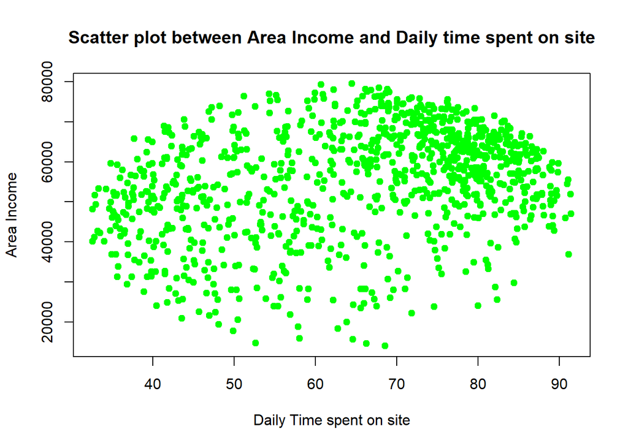

```r
# scatter plot between Area Income and daily time spent on site
plot(dataset$Daily.Time.Spent.on.Site,dataset$Area.Income,main="Scatter plot between Area Income and Daily time spent on site",col='green',xlab="Daily Time spent on site",ylab="Area Income",pch=19)
```

The scatter plot between daily time spent on site and area income shows us that those with an area income between 50,000 and 70,000 are the ones who spend more time on site.

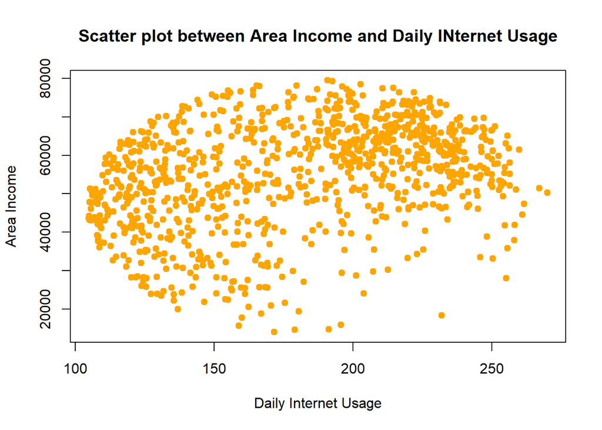

```r
# scatter plot between Area Income and daily time spent on site
plot(dataset$Daily.Internet.Usage,dataset$Area.Income,main="Scatter plot between Area Income and Daily INternet Usage",col='orange',xlab="Daily Internet Usage",ylab="Area Income",pch=19)
```

The scatter plot of daily internet usage and Area Income shows us that between income 60,000 and 75,000 spent more on internet while those between income 35,000 and 50,000 spent less on internet.

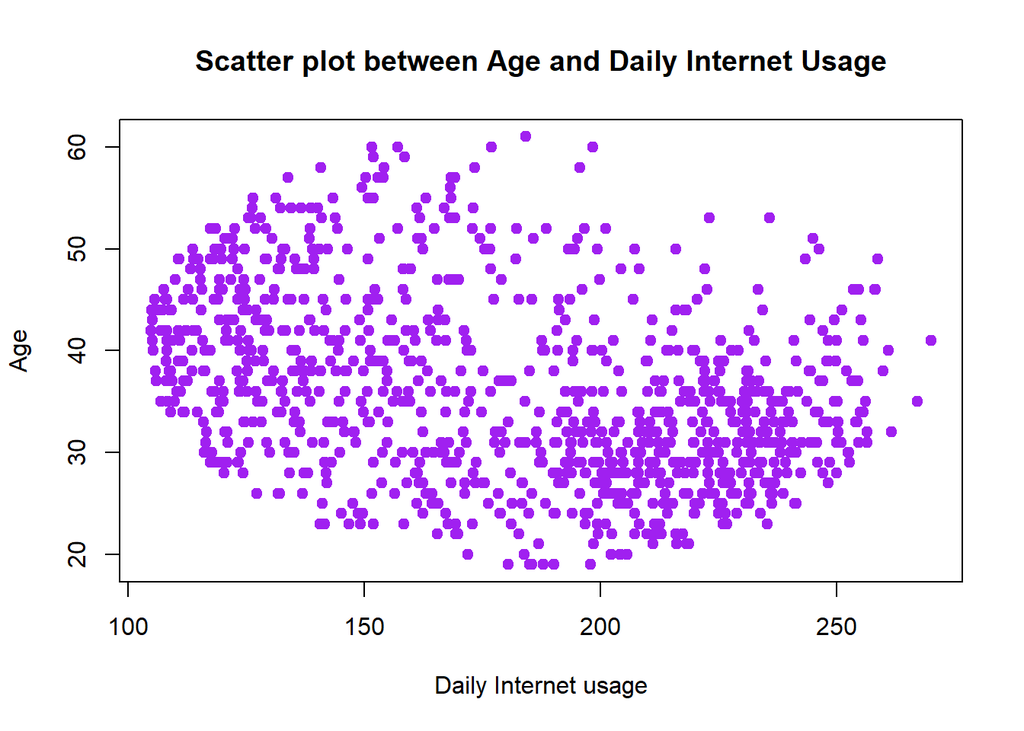

```r
# scatter plot between age and daily Internet Usage
plot(dataset$Daily.Internet.Usage,dataset$Age,main="Scatter plot between Age and Daily Internet Usage",col='purple',xlab="Daily Internet usage",ylab="Age",pch=19)
```

The scatter plot of daily internet usage and age shows us that between the ages 25 years and 40 years spent more on internet.

## Conclusion

1.Majority of the respondents were females.

2.All the variables have a negative correlation with Clicked on Ad apart from Age.

3.There is a positive correlation between Area Income and Daily Time Spent on Site.

4.There is a positive correlation between Area Income and Daily Internet Usage.

5.There is a positive correlation between Age and Clicked on Ad.

6.Respondents aged between 25 years and 40 years spent more time on the internet.

7.Respondents aged between 25 years and 40 years spent a lot on Internet.Thisis supported by the fact that they spent alot of time on the internet.

From our Analysis we found out that the elderly are more likely to click on the Ads since it had a positive correlation.

From our analysis we found out that the low income earners are more likely to click on the Ads since they had a negative correlation.